# Analysis for Project

# Introduction

Being part of two stigmatized groups, LGBTQ people of color experience marginalization within both their racial/ethnic communities and the mainstream LGBTQ community. There is evidence that the mainstream LGBT community, movement, and organizations remain normatvely white despite appeals to diversity (Ward 2008) and tend not to meet unique needs of LGBTQ people of color (Acosta 2014; Alimahomed 2012; Moore 2011; Ocampo 2014). While previous studies show that queer people of color may experience discomfort and exclusion in relation to the broader LGBT movement and organizations, little is known about which factors contribute to LGBT POCs racial discomfort in these spaces and their attitudes about the ways mainstream LGBTQ organizations address issues of race. This project tests whether level of education is associated with racial discomfort and beliefs about mainstream LGBT organizations’ handling of racial issues among LGBTQ people of color. Educational attainment was chosen as the independent variable because there is some evidence that educaitonal attainment among nonwhites is associated with with increased racial consciousness and politicized views on race (Wodtke 2012).

My main questions are: What is the relationship between level of education and racial discomfort in the general LGBT commuity among LGBTQ people of color? Also, what is the relationship between level of education and beliefs about whether mainstream LGBT organizations are adequately addressing racial issues among LGBTQ people of color?

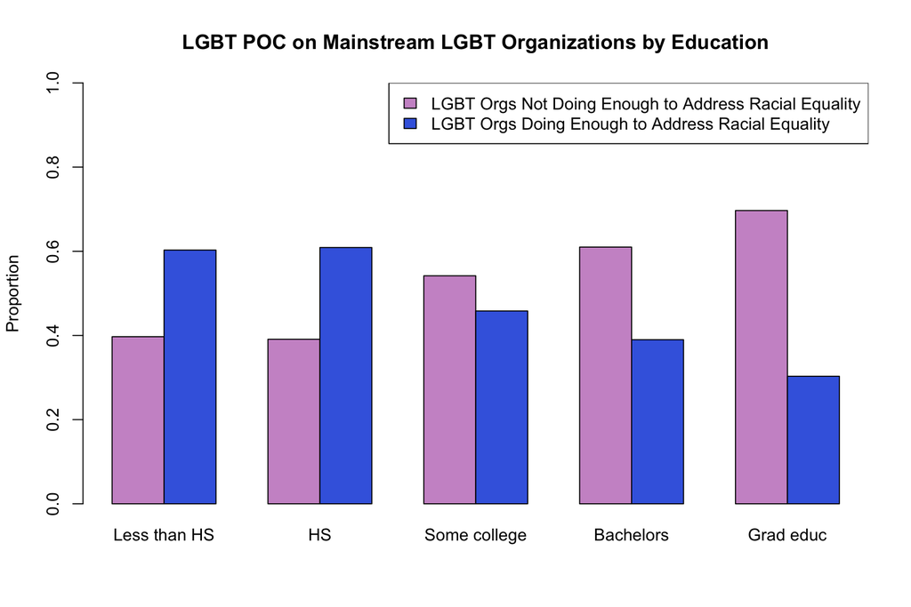

Barplot: Education and Beliefs About LGBT Orgs on Race

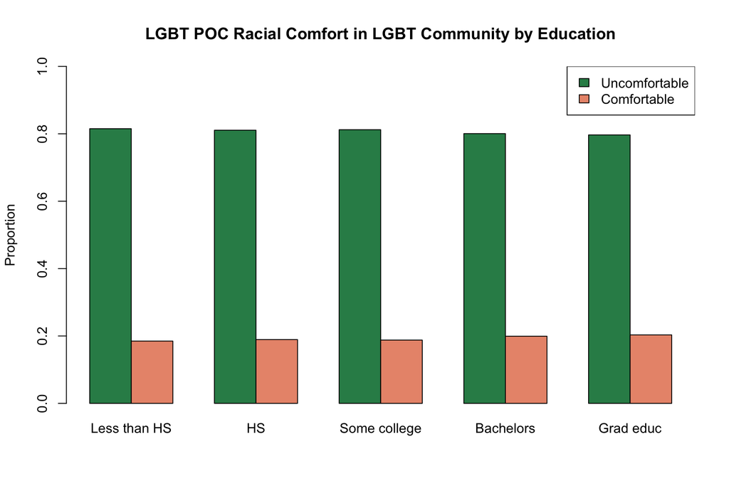

Barplot: Education and Racial Comfort

# Results

The first comparative barplot that demonstrates the distribution of the racialeq variable by level of education shows a strong pattern. The majority of those sampled with a high school degree or less believe that mainstream LGBT organizations are doing enough to address racial equality, while the majority of those with some college, Bachelors degrees, and graduate education were more likely to report that they thought mainstream LGBT organizations are not doing enough to address issues of racial equality.

The second comparative barplot shows the distribution of the racial discomfort variable by level of education. It suggests a different pattern, indicating that, regardless of educational attainment, the majority of LGBT POC sampled reported feeling generally uncomfortable in the broader LGBT community because of their race.

In contrast, level of education seems to have no relationship with racial discomfort in the LGBT community. Rather, the majority LGBTQ people of color report feelings of racial discomfort regardless of education, which is something worth noting. This suggests that the mainstream LGBT community may not be doing enough to include LGBTQ people of color.